# AOOI3_Aula07_DiagramasClassesDominio

### 9.1.1.3. Associações Ternárias

- **Grau de uma associação**:
  - é a quantidade de classes envolvidas na associação.
- Normalmente são **binárias** (2 classes), ligação entre objetos de 2 classes.
- Grau maior que 2, com a ligação entre 3 classes, conhecido como ternária.
- É a **Associação de três classes**.
- Exibida com um grande losango ligando as classes.

**Figura 23: Relacionamento de Associações Ternárias**

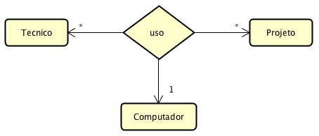

Fonte: Autoria própria

- Exemplo: Um técnico utiliza exatamente um computador para cada projeto em que trabalha. Cada computador pertence a um técnico para cada projeto. Note que, um técnico pode trabalhar com vários projetos e usar diferentes computadores para diferentes projetos.

### 9.2. Associações por Agregações ou Composições

- **Relação Todo-Parte**: é a relação entre dois objetos que indica que um deles está contido no outro.
- Um objeto contém o outro.
- Na UML, são divididas em **dois tipos**:
  - agregação.
  - composição.
- **Agregações / composições são assimétricas**: se um objeto A é parte de um objeto B, o objeto B não pode ser parte do objeto A.
- **Agregações / composições propagam comportamento**: se um comportamento se aplica a um TODO, indica que o mesmo comportamento se aplica às suas partes.
- **Agregações/composições são criadas e destruídas pelo TODO**. Na classe do objeto TODO são definidas operações para adicionar ou remover as partes.

### 9.2.1. Associações por Agregações

- Agregação é um caso particular da associação. Agregação funciona de forma similar à associação, porém, a classe que agrega uma outra consegue existir mesmo se esta outra não existir.
- Suponhamos que a classe Pagamento agregue a classe Comprovante. Mesmo que o objeto de Comprovante não seja gerado por algum motivo, o objeto de Pagamento pode ter sido efetuado com sucesso.
- Palavras chaves usadas para identificar uma agregação são:
  - "consiste em", "contém", "é parte de".
- Forma especializada de associação na qual um todo é relacionado com suas partes.
- **Conhecida como** relação de conteúdo.
- **Representada** como uma linha de associação com um losango junto à **Classe agregadora**, **todo-agregado**.
- **Multiplicidade** é representada da mesma maneira que nas associações.
- **Relação todo-parte** entre dois objetos indica que um dos objetos está contido no outro, ou um objeto contém o outro.  
  **IMPORTANTE**:
- **Agregação somente poderá ocorrer entre 2 classes**.
- **Tipo de relacionamento indica que ambas as classes podem "viver" de forma independente**, ou seja, **não existe uma ligação forte** entre as duas classes.
- **Classe todo-agregado** recebe o losango e a outra parte é chamada de **Classe parte-constituinte**.

**Figura 24: Relacionamento de Associações por Agregações**

- Um proprietário de um apartamento possui um depósito. Por exemplo, se ele decidir vender o depósito para outra pessoa do prédio, cada objeto “viverá” separadamente.

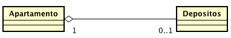

Fonte: Autoria própria

**Figura 25: Relacionamento de Associações por Agregações**

- Uma associação esportiva é formada por diversas equipes.
- E cada uma delas é formada por diversos jogadores.
- Por outro lado, um jogador pode fazer parte de diversas equipes.

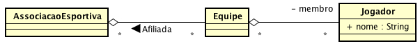

Fonte: Autoria própria

### 9.3. Associações por Composições

- É uma especialização de agregação, na qual as partes não existem independentemente do objeto completo.
- Ideia de composição pode ser interpretada utilizando o exemplo de um objeto da Classe Veículo. Suponha que um Veículo seja formado por várias peças. Logo: carro é composto de portas, janelas, rodas, pneus.
- Diferença da composição é justamente a relação forte que existe entre as classes, como no exemplo do Veículo que não poderá se locomover se não possuir rodas.  
  **IMPORTANTE**:
- **Situação semelhante à agregação entre duas classes**, porém os objetos da **classe parte** não podem "viver" quando o todo é destruído.
- **Classe todo-composta** recebe o losango preenchido, e a outra parte é chamada de **Classe parte-componente**.
- Ambas "vivem unidas" de forma dependente, ou seja, **existe uma ligação forte entre elas**.

**Figura 26: Relacionamento de Associações por Composições**

- Um pedido de compra com vários itens. Cada item corresponde a um único produto.

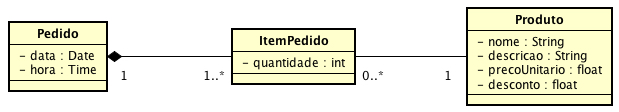

Fonte: Autoria própria

**Figura 27: Relacionamento de Associações por Composições**

- Um automóvel que possui várias partes: um motor e 4 rodas.

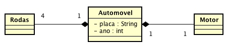

Fonte: Autoria própria

**Figura 28: Relacionamento de Associações por Composições**

- Um livro com capítulos que contém seções que contém parágrafos.

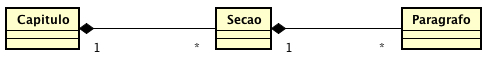

Fonte: Autoria própria

### 9.3.1. Como Identificar se é Agregação ou Composição ?

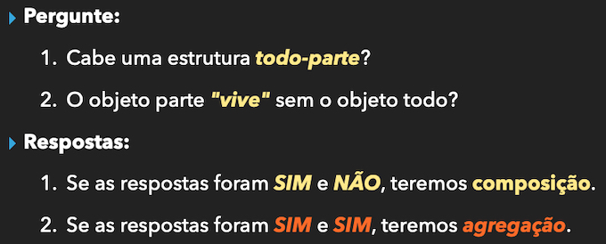

### 9.4. Relacionamentos de Dependência

- **Dependência** é um relacionamento direcionado que é usado para mostrar que algum elemento UML ou um conjunto de elementos requer, precisa ou depende de outros elementos do modelo para especificação ou implementação.
- Por causa disso, a dependência é **chamada de relacionamento fornecedor-cliente**, em que o fornecedor fornece algo ao cliente e, assim, o cliente é, em certo sentido, incompleto, enquanto semanticamente ou estruturalmente dependente do (s) elemento (s) do fornecedor.
- A **modificação do fornecedor pode afetar os elementos do cliente**.
- **Dependência é um relacionamento entre elementos nomeados**, que em UML inclui muitos elementos diferentes, por exemplo: classes, interfaces, componentes, artefatos, pacotes e etc.

### 9.5. Generalização ou Herança

- O modelo de classes além de representar os **relacionamentos entre objetos das classes**, também pode representar relacionamentos entre as classes.
- Conhecidos como: relações de **generalidade ou especificidade**. Por exemplo:
  - Conceito mamífero é mais genérico que humano.
  - Conceito carro é mais específico que veículo.
- O relacionamento de herança conhecido como: generalização/ especialização ou gen/espec.
- **Exemplo**: Classes A e B.
  - Se A é uma classe genérica de B, então B é uma classe especialista de A.  
    **IMPORTANTE**:
- **Subclasse ou subtipo ou classe herdeira**: utilizado para denotar a classe que herda as propriedades de outra classe por meio de uma generalização. **É a especialização da superclasse**.
- **Superclasse ou supertipo ou classe base**: utilizado para denotar a classe que passa suas propriedades para outra classe. **É a generalização da subclasse**.
- **Ancestral ou descendente**.

**Figura 29: Relacionamento de Herança**

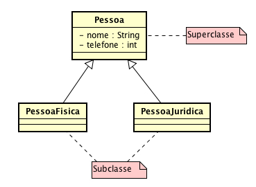

Fonte: Autoria própria

### 9.5.1. Relacionamentos de Generalização

- A **Generalização é um relacionamento entre um elemento geral e um outro mais específico**.
- Elemento mais **específico possui todas as características do elemento geral** e contém ainda **mais particularidades**.
- Objeto mais **específico pode ser usado como uma instância do elemento mais geral**.
- **Generalização**, também **chamada de herança**, permite a criação de elementos especializados em outros.
- **Existem alguns tipos de generalizações** que variam em sua utilização a partir da situação.
- **São elas**: generalização normal e restrita. As generalizações restritas se dividem em generalização de sobreposição, disjuntiva, completa e incompleta.

### 9.5.1.1. Generalização normal

- **Generalização normal**: a classe mais específica, chamada de subclasse, herda tudo da classe mais geral, chamada de superclasse.
- Atributos, operações e todas as associações são herdados.
- Classe pode ser tanto uma subclasse quanto uma superclasse, se ela estiver numa hierarquia de classes que é um gráfico onde as classes estão ligadas através de generalizações.  
  **IMPORTANTE**
- **Generalização normal é representada por uma linha entre as duas classes que fazem o relacionamento, sendo que se coloca uma seta no lado da linha onde se encontra a superclasse indicando a generalização**.

**Figura 30: Relacionamento de Generalização Normal**

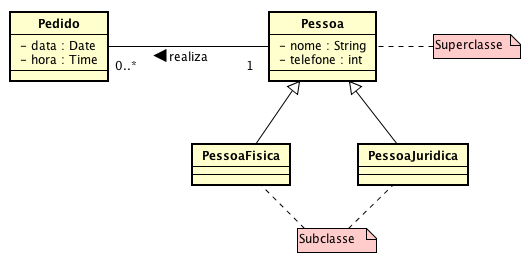

Fonte: Autoria própria

### 9.5.1.2. Conceitos de Herança

- Propriedades de Transitividade e Assimetria:
  - **Transitividade**: indica que uma classe em uma hierarquia herda tanto propriedades e relacionamentos de sua superclasse imediata quanto de duas não imediatas (classe em nível mais alto da hierarquia).
  - **Assimetria**: dadas duas classes A e B, se A for uma generalização de B, então B não pode ser uma generalização de A. Ou seja: não pode haver ciclos em uma hierarquia de herança.
    - Aplica-se o refinamento de classes para identificar as abstrações mais genéricas ou mais específicas. **Regra da substituição**.
    - **Pergunta**: A é um tipo de B ? Se "SIM" possivelmente A será subclasse de B.

**Figura 31: Exemplos de Hierarquia de Herança**

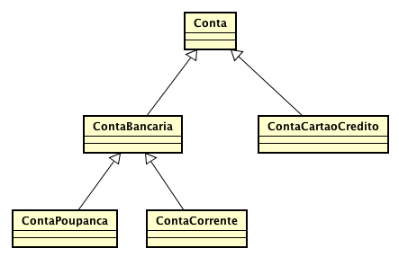

Fonte: Autoria própria

**Figura 32: Exemplos de Hierarquia de Herança**

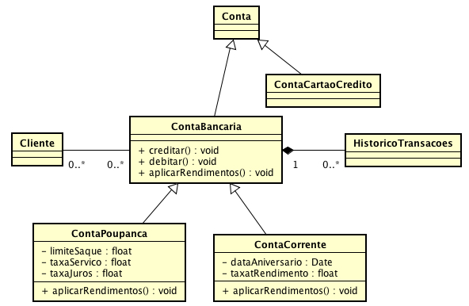

Fonte: Autoria própria

### 9.5.2. Generalização RESTRITA

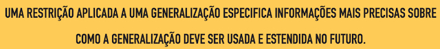

- As restrições a seguir definem as generalizações restritas com mais de uma subclasse:
- **Sobreposta**: Posteriormente podem ser criadas subclasses que herdam de mais de uma subclasse. (conhecido com Herança Múltipla).
- **Disjunta**: Quaisquer subclasses criadas posteriormente poderão herdar de somente uma subclasse.
- **Completa**: Todas as subclasses possíveis foram enumeradas na hierarquia.
- **Incompleta**: Nem todas as subclasses da hierarquia foram enumeradas.

### Generalização RESTRITA INCOMPLETA E ???

**Figura 33: Exemplos de Hierarquia de Herança**

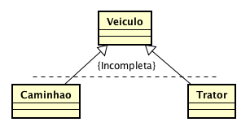

Fonte: Autoria própria

### Generalização RESTRITA COMPLETA E DISJUNTA

**Figura 34: Exemplos de Hierarquia de Herança**

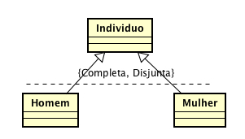

Fonte: Autoria própria

### Generalização RESTRITA INCOMPLETA E SOBREPOSTA

**Figura 35: Exemplos de Hierarquia de Herança**

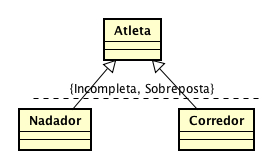

Fonte: Autoria própria

### Generalização RESTRITA INCOMPLETA E DISJUNTA

**Figura 36: Exemplos de Hierarquia de Herança**

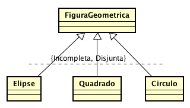

Fonte: Autoria própria

### Pensem em exemplos de GENERALIZAÇÃO RESTRITA COMPLETA E SOBREPOSTA ???

### Referências

- Esta aula foi elaborada a partir do conteúdo disponibilizado em cada um dos links indicados no próprio texto.
- GUEDES, G. T. A. UML 2 - **UMA ABORDAGEM PRÁTICA**. [S.L.]: NOVATEC, 2011.
- MEDEIROS, Ernani - **Desenvolvendo Software com UML 2.0 Definitivo** - Editora Pearson Makron Books.
- BOOCH, Grady; RUMBAUGH, James; JACOBSON, Ivar - **UML Guia do Usuário** - 2a. Edição - Editora Campus (Elsevier).

### Perguntas

- Esclareça suas eventuais dúvidas durante as aulas.
- Ou pelo *E-mail*: paulagiancoli@ifsp.edu.br.
- Ou acesse [Github Ana Giancoli](https://anagiancoli.github.io) e solicite atendimento para o componente curricular.
- Ou pelo *Fórum* do componente curricular.

*ADS - AOO - 3o. módulo*.  
Modelo e formato elaborado por profa. Ana Paula Müller Giancoli - BSD 2-Clause License. - Setembro.2020.